# Business Statistic Project 2

## Axis Insurance Exploratory Data Analysis

### Import Library

```python
import pandas as pd
import seaborn as sns
import numpy as np
import matplotlib.pyplot as plt
sns.set(color_codes=True)
#matplotlib inline
import warnings
warnings.filterwarnings('ignore')
from scipy.stats import skew, norm, probplot, boxcox, f_oneway
```

#### Loading and View of the data set

with a view of the data, it will give me an understaning of the data.

```python
data = pd.read_csv('AxisInsurance.csv')
data.head()
```

|  | age | sex | bmi | children | smoker | region | charges |
| --- | --- | --- | --- | --- | --- | --- | --- |
| 0 | 19 | female | 27.900 | 0 | yes | southwest | 16884.92400 |
| 1 | 18 | male | 33.770 | 1 | no | southeast | 1725.55230 |
| 2 | 28 | male | 33.000 | 3 | no | southeast | 4449.46200 |
| 3 | 33 | male | 22.705 | 0 | no | northwest | 21984.47061 |
| 4 | 32 | male | 28.880 | 0 | no | northwest | 3866.85520 |

```python
data2 = pd.read_csv('AxisInsurance.csv')
```

### In the cells below Taking a look at:

1. Number of rows and columns in the spread sheet
2. Type of data in the sheet
3. If the are missing data in the columns

```python
data.shape
```

```
(1338, 7)
```

```python
data.count()
```

```
age         1338
sex         1338
bmi         1338
children    1338
smoker      1338
region      1338
charges     1338
dtype: int64
```

```python
data.info()
```

```
<class 'pandas.core.frame.DataFrame'>
RangeIndex: 1338 entries, 0 to 1337
Data columns (total 7 columns):
 #   Column    Non-Null Count  Dtype
---  ------    --------------  -----
 0   age       1338 non-null   int64
 1   sex       1338 non-null   object
 2   bmi       1338 non-null   float64
 3   children  1338 non-null   int64
 4   smoker    1338 non-null   object
 5   region    1338 non-null   object
 6   charges   1338 non-null   float64
dtypes: float64(2), int64(2), object(3)
memory usage: 73.3+ KB
```

```python
data["sex"]=data["sex"].astype('category')
data["smoker"]=data["smoker"].astype('category')
data["region"]=data["region"].astype('category')
data.dtypes
```

```
age            int64
sex         category
bmi          float64
children       int64
smoker      category
region      category
charges      float64
dtype: object
```

```python
data.info()
```

```
<class 'pandas.core.frame.DataFrame'>
RangeIndex: 1338 entries, 0 to 1337
Data columns (total 7 columns):
 #   Column    Non-Null Count  Dtype
---  ------    --------------  -----
 0   age       1338 non-null   int64
 1   sex       1338 non-null   category
 2   bmi       1338 non-null   float64
 3   children  1338 non-null   int64
 4   smoker    1338 non-null   category
 5   region    1338 non-null   category
 6   charges   1338 non-null   float64
dtypes: category(3), float64(2), int64(2)
memory usage: 46.2 KB
```

```python
data.isna().sum()
```

```
age         0
sex         0
bmi         0
children    0
smoker      0
region      0
charges     0
dtype: int64
```

## Check the statistcal summary or 5-point summary of data

```python
data.describe()
```

|  | age | bmi | children | charges |
| --- | --- | --- | --- | --- |
| count | 1338.000000 | 1338.000000 | 1338.000000 | 1338.000000 |
| mean | 39.207025 | 30.663397 | 1.094918 | 13270.422265 |
| std | 14.049960 | 6.098187 | 1.205493 | 12110.011237 |
| min | 18.000000 | 15.960000 | 0.000000 | 1121.873900 |
| 25% | 27.000000 | 26.296250 | 0.000000 | 4740.287150 |
| 50% | 39.000000 | 30.400000 | 1.000000 | 9382.033000 |
| 75% | 51.000000 | 34.693750 | 2.000000 | 16639.912515 |
| max | 64.000000 | 53.130000 | 5.000000 | 63770.428010 |

```python
data.describe(include=["category"])
```

|  | sex | smoker | region |
| --- | --- | --- | --- |
| count | 1338 | 1338 | 1338 |
| unique | 2 | 2 | 4 |
| top | male | no | southeast |
| freq | 676 | 1064 | 364 |

1. Explore the dataset and extract insights using Exploratory Data Analysis.
2. Prove (or disprove) that the medical claims made by the people who smoke is greater than those who don't? [Hint- Formulate a hypothesis and prove/disprove it]
3. Prove (or disprove) with statistical evidence that the BMI of females is different from that of males.
4. Is the proportion of smokers significantly different across different regions? [Hint : Create a contingency table/cross tab, Use the function : stats.chi2_contingency()]
5. Is the mean BMI of women with no children, one child, and two children the same? Explain your answer with statistical evidence. *Consider a significance level of 0.05 for all tests.

# Univariant analysis of the variables

```python
def histogram_boxplot(feature, figsize=(15,10), bins = None):
    """ Boxplot and histogram combined
    feature: 1-d feature array
    figsize: size of fig (default (9,8))
    bins: number of bins (default None / auto)
    """
    f2, (ax_box2, ax_hist2) = plt.subplots(nrows = 2,
                                           sharex = True,
                                           gridspec_kw = {"height_ratios": (.25, .75)},
                                           figsize = figsize
                                           )
    sns.boxplot(feature, ax=ax_box2, showmeans=True, color='violet')
    sns.distplot(feature, kde=F, ax=ax_hist2, bins=bins,palette="winter") if bins else sns.distplot(feature, kde=False, ax=ax_hist2) # For histogram
    ax_hist2.axvline(np.mean(feature), color='green', linestyle='--')
    ax_hist2.axvline(np.median(feature), color='black', linestyle='-')
```

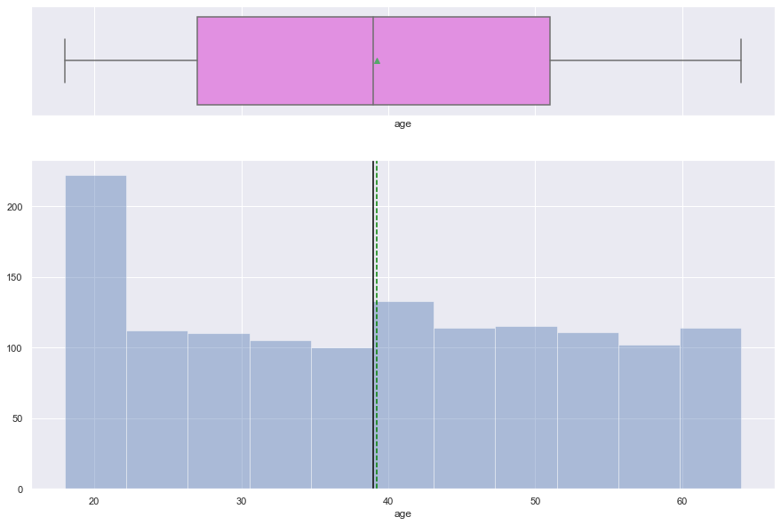

```python
histogram_boxplot(data["age"])
```

##### Observation

1. The mean and median age is close.
2. skewed to the right.
3. highest count in 18years

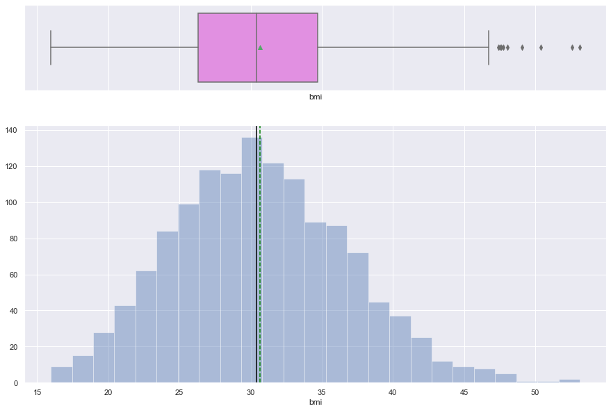

```python
histogram_boxplot(data["bmi"])
```

##### Observation

1. BMI has a normal distribution
2. Mean and median in close
3. Few outlier

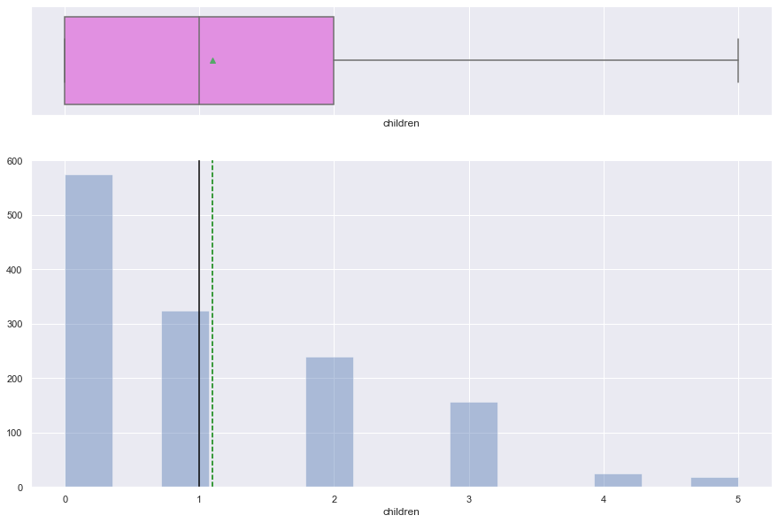

```python
histogram_boxplot(data["children"])
```

##### Observation

1. The data is skewed to the right
2. Mean and medium are in close proxmity

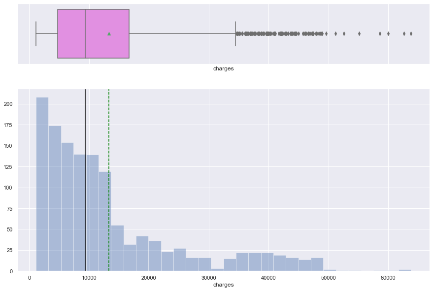

```python
histogram_boxplot(data["charges"])
```

##### Observation

1. Charges is skwed to the right
2. there are alot of outliers
3. the median is 10,000
4. most of the medical claims are 10,000 and below.

```python
def perc_on_bar(plot, feature):
    '''
    plot
    feature: categorical feature
    the function won't work if a column is passed in hue parameter
    '''
    total = len(feature) # length of the column
    for p in ax.patches:
        percentage = '{:.1f}%'.format(100 * p.get_height()/total) # percentage of each class of the category
        x = p.get_x() + p.get_width() / 2 - 0.05 # width of the plot
        y = p.get_y() + p.get_height()           # hieght of the plot
        ax.annotate(percentage, (x, y), size = 12) # annotate the percantage
    plt.show() # show the plot
```

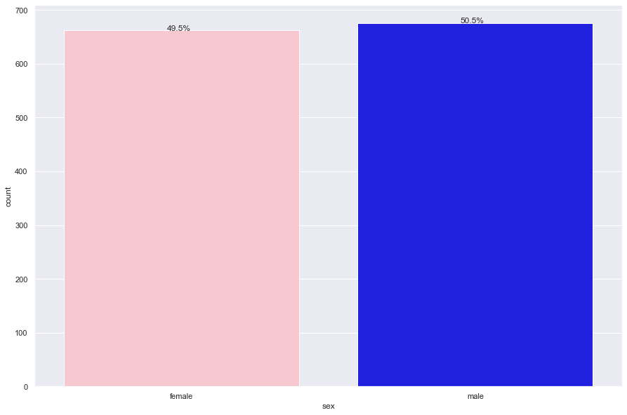

```python
plt.figure(figsize=(15,10))
ax = sns.countplot(data["sex"],palette=('pink','blue'))
perc_on_bar(ax,data["sex"])
```

##### Observation

1. Male insurance claims are slighly high than female

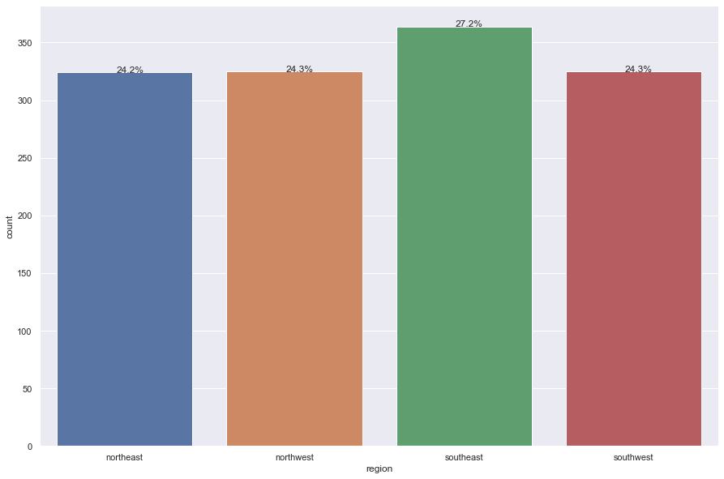

```python
plt.figure(figsize=(15,10))
ax = sns.countplot(data["region"])
sns.color_palette("hls", 4)
perc_on_bar(ax,data["region"])
```

##### Observation

1. Most of the medical insurance claims are from the southeast though other regions are equally distributed

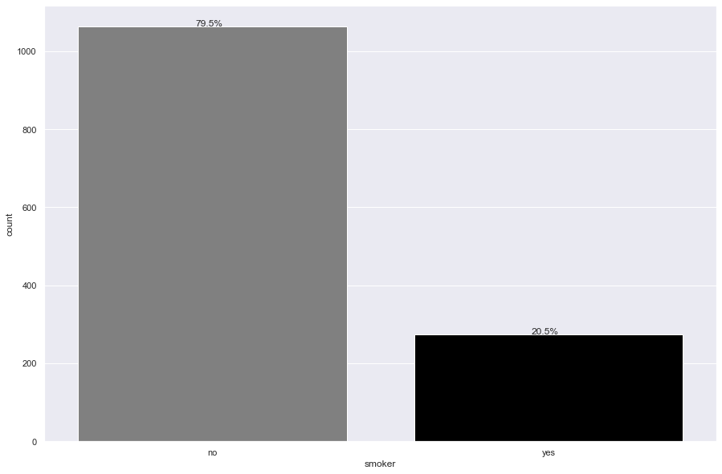

```python
plt.figure(figsize=(15,10))
ax = sns.countplot(data["smoker"],palette=('grey','black'))
perc_on_bar(ax,data["smoker"])
```

### observation

The non-smokers are significantly high than smokers

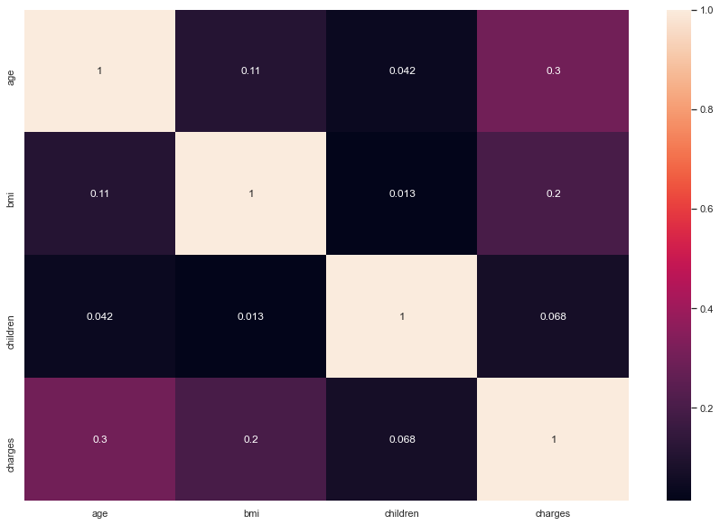

```python
plt.figure(figsize=(15,10))
sns.heatmap(data.corr(),annot=True)
plt.show()
```

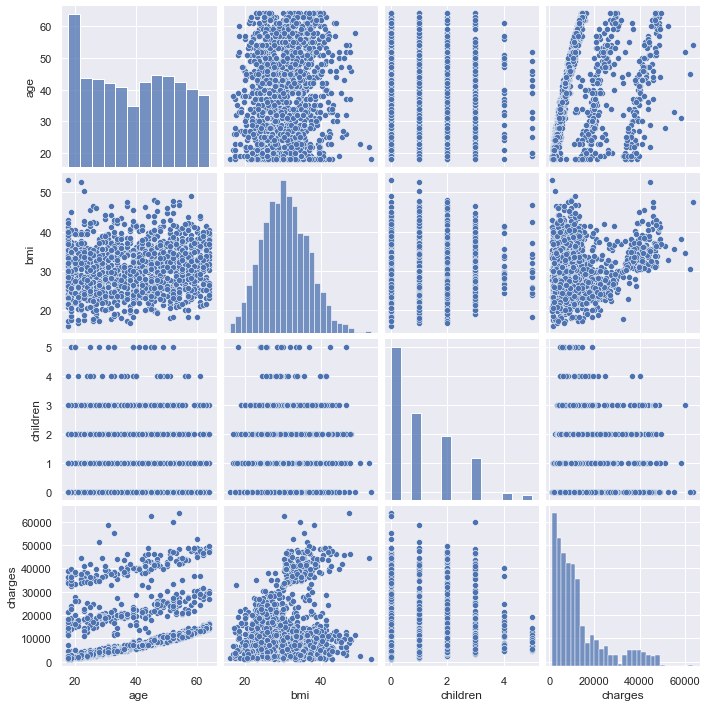

```python
sns.pairplot(data)
```